# examples_1203

Find $w$.

You can simply find half the difference of the roots.

$$h=\frac{16.2-50.5}{2}$$

$$w=17.15$$

A [quadratic function](https://en.wikipedia.org/wiki/Quadratic_function) is graphed below. Notice the curve is a [parabola](https://en.wikipedia.org/wiki/Parabola) with a vertical axis of symmetry.

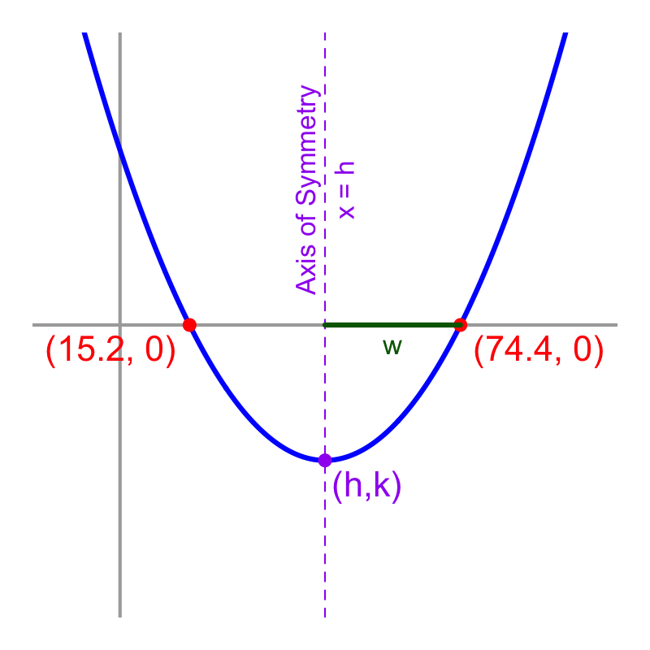

As shown in the graph, the parabola has roots at $15.2$ and $74.4$. I've marked the vertex with $(h,k)$ and the distance from the axis of symmetry to a root with $w$.

Find $w$.

You can simply find half the difference of the roots.

$$h=\frac{15.2-74.4}{2}$$

$$w=29.6$$

A [quadratic function](https://en.wikipedia.org/wiki/Quadratic_function) is graphed below. Notice the curve is a [parabola](https://en.wikipedia.org/wiki/Parabola) with a vertical axis of symmetry.

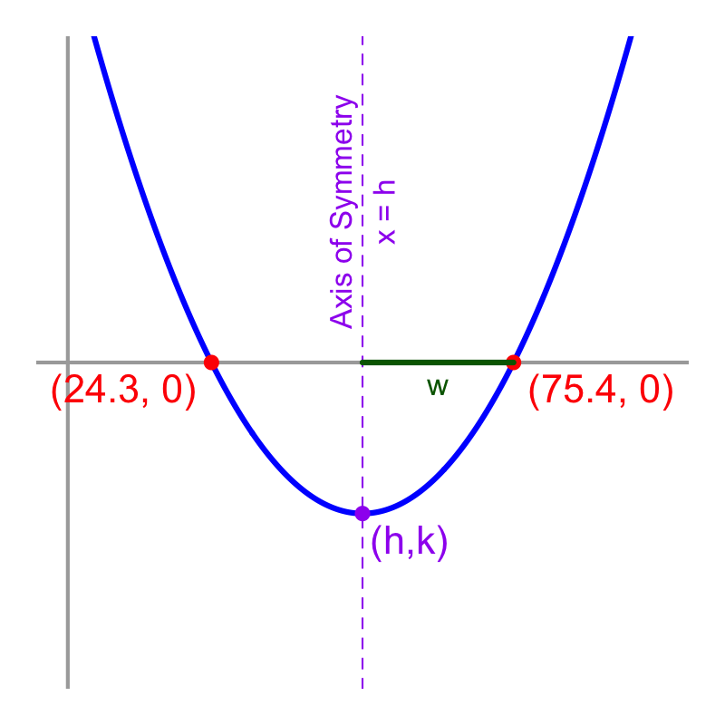

As shown in the graph, the parabola has roots at $24.3$ and $75.4$. I've marked the vertex with $(h,k)$ and the distance from the axis of symmetry to a root with $w$.

Find $w$.

You can simply find half the difference of the roots.

$$h=\frac{24.3-75.4}{2}$$

$$w=25.55$$

Consider the [quadratic function](https://en.wikipedia.org/wiki/Quadratic_function) defined below.

$$f(x)~=~-6x^2-5x+7$$

Below, I've graphed $y=f(x)$, and I've included the axis of symmetry as a dashed purple line and the vertex as a filled red dot.

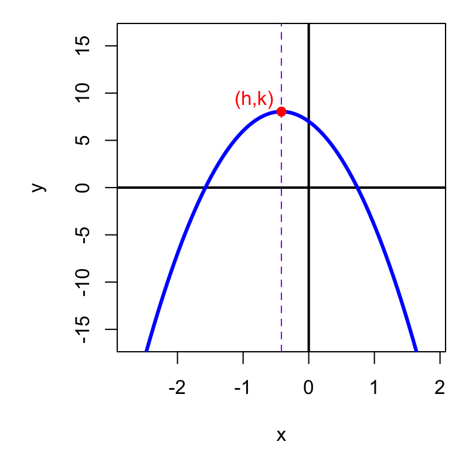

Using [the geometric significance of the quadratic formula](https://en.wikipedia.org/wiki/Quadratic_formula#Geometric_significance), calculate $h$, the horizontal coordinate of the vertex. *The tolerance is $\pm 0.01$.*

Look at the quadratic formula, which tells us if our quadratic function is in standard form, like $y=ax^2+bx+c$, then:

$$\text{roots of quadratic function} ~=~
\frac{-b}{2a}\pm\frac{\sqrt{b^2-4ac}}{2a}$$

We were given a quadratic function in standard form. Identify the parameters.

- The quadratic coefficient: $a=-6$
- The linear coefficient: $b=-5$
- The constant: $c=7$

The [the geometric significance of the quadratic formula](https://en.wikipedia.org/wiki/Quadratic_formula#Geometric_significance) tells us that $h=\frac{-b}{2a}$ and the distance of the roots to the axis of symmetry is $\frac{\sqrt{b^2-4ac}}{2a}$. Use the formula to calculate $h$.

$$\begin{align}
h &= \frac{-b}{2a} \\\\
&= \frac{-(-5)}{2(-6)} \\\\
&= -0.4166667
\end{align}$$

- The axis of symmetry is line $x=-0.4166667$.
- The vertex is point $(-0.4166667,\,8.0416667)$

Consider the [quadratic function](https://en.wikipedia.org/wiki/Quadratic_function) defined below.

$$f(x)~=~-8x^2+6x+5$$

Below, I've graphed $y=f(x)$, and I've included the axis of symmetry as a dashed purple line and the vertex as a filled red dot.

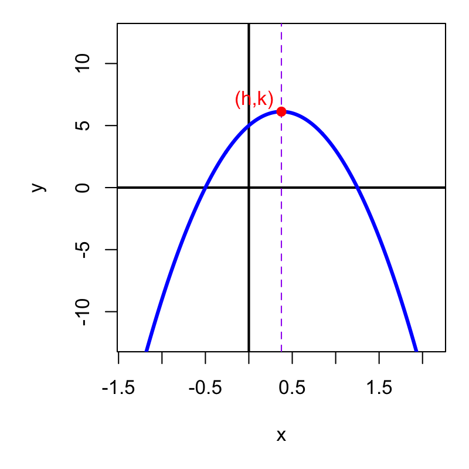

Using [the geometric significance of the quadratic formula](https://en.wikipedia.org/wiki/Quadratic_formula#Geometric_significance), calculate $h$, the horizontal coordinate of the vertex. *The tolerance is $\pm 0.01$.*

Look at the quadratic formula, which tells us if our quadratic function is in standard form, like $y=ax^2+bx+c$, then:

$$\text{roots of quadratic function} ~=~
\frac{-b}{2a}\pm\frac{\sqrt{b^2-4ac}}{2a}$$

We were given a quadratic function in standard form. Identify the parameters.

- The quadratic coefficient: $a=-8$
- The linear coefficient: $b=6$
- The constant: $c=5$

The [the geometric significance of the quadratic formula](https://en.wikipedia.org/wiki/Quadratic_formula#Geometric_significance) tells us that $h=\frac{-b}{2a}$ and the distance of the roots to the axis of symmetry is $\frac{\sqrt{b^2-4ac}}{2a}$. Use the formula to calculate $h$.

$$\begin{align}
h &= \frac{-b}{2a} \\\\
&= \frac{-(6)}{2(-8)} \\\\
&= 0.375
\end{align}$$

- The axis of symmetry is line $x=0.375$.
- The vertex is point $(0.375,\,6.125)$

Consider the [quadratic function](https://en.wikipedia.org/wiki/Quadratic_function) defined below.

$$f(x)~=~5x^2+7x-10$$

Below, I've graphed $y=f(x)$, and I've included the axis of symmetry as a dashed purple line and the vertex as a filled red dot.

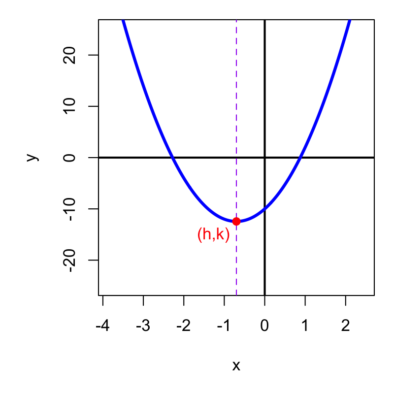

Using [the geometric significance of the quadratic formula](https://en.wikipedia.org/wiki/Quadratic_formula#Geometric_significance), calculate $h$, the horizontal coordinate of the vertex. *The tolerance is $\pm 0.01$.*

Look at the quadratic formula, which tells us if our quadratic function is in standard form, like $y=ax^2+bx+c$, then:

$$\text{roots of quadratic function} ~=~
\frac{-b}{2a}\pm\frac{\sqrt{b^2-4ac}}{2a}$$

We were given a quadratic function in standard form. Identify the parameters.

- The quadratic coefficient: $a=5$
- The linear coefficient: $b=7$
- The constant: $c=-10$

The [the geometric significance of the quadratic formula](https://en.wikipedia.org/wiki/Quadratic_formula#Geometric_significance) tells us that $h=\frac{-b}{2a}$ and the distance of the roots to the axis of symmetry is $\frac{\sqrt{b^2-4ac}}{2a}$. Use the formula to calculate $h$.

$$\begin{align}
h &= \frac{-b}{2a} \\\\
&= \frac{-(7)}{2(5)} \\\\
&= -0.7
\end{align}$$

- The axis of symmetry is line $x=-0.7$.
- The vertex is point $(-0.7,\,-12.45)$

Consider the [quadratic function](https://en.wikipedia.org/wiki/Quadratic_function) defined below.

$$f(x)~=~3x^2-10x-5$$

Below, I've graphed $y=f(x)$, and I've included the axis of symmetry as a dashed purple line and the vertex as a filled red dot.

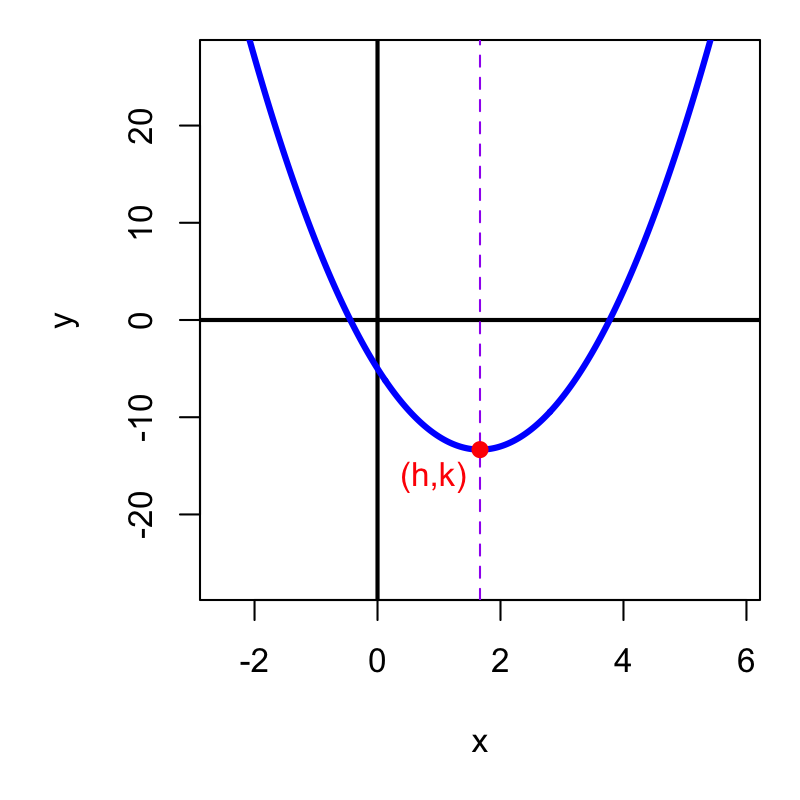

Using [the geometric significance of the quadratic formula](https://en.wikipedia.org/wiki/Quadratic_formula#Geometric_significance), calculate $h$, the horizontal coordinate of the vertex. *The tolerance is $\pm 0.01$.*

Look at the quadratic formula, which tells us if our quadratic function is in standard form, like $y=ax^2+bx+c$, then:

$$\text{roots of quadratic function} ~=~
\frac{-b}{2a}\pm\frac{\sqrt{b^2-4ac}}{2a}$$

We were given a quadratic function in standard form. Identify the parameters.

- The quadratic coefficient: $a=3$
- The linear coefficient: $b=-10$
- The constant: $c=-5$

The [the geometric significance of the quadratic formula](https://en.wikipedia.org/wiki/Quadratic_formula#Geometric_significance) tells us that $h=\frac{-b}{2a}$ and the distance of the roots to the axis of symmetry is $\frac{\sqrt{b^2-4ac}}{2a}$. Use the formula to calculate $h$.

$$\begin{align}
h &= \frac{-b}{2a} \\\\
&= \frac{-(-10)}{2(3)} \\\\
&= 1.6666667
\end{align}$$

- The axis of symmetry is line $x=1.6666667$.
- The vertex is point $(1.6666667,\,-13.3333333)$

Consider the [quadratic function](https://en.wikipedia.org/wiki/Quadratic_function) defined below.

$$f(x)~=~8x^2-12x-10$$

Below, I've graphed $y=f(x)$, and I've included the axis of symmetry as a dashed purple line and the vertex as a filled red dot.

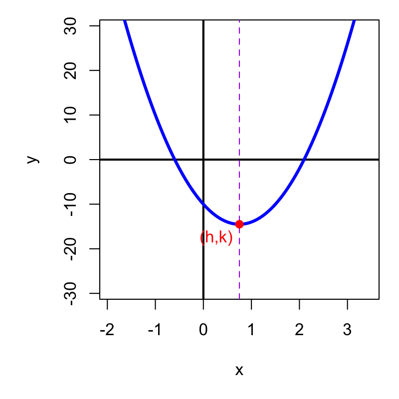

Using [the geometric significance of the quadratic formula](https://en.wikipedia.org/wiki/Quadratic_formula#Geometric_significance), calculate $h$, the horizontal coordinate of the vertex. *The tolerance is $\pm 0.01$.*

Look at the quadratic formula, which tells us if our quadratic function is in standard form, like $y=ax^2+bx+c$, then:

$$\text{roots of quadratic function} ~=~
\frac{-b}{2a}\pm\frac{\sqrt{b^2-4ac}}{2a}$$

We were given a quadratic function in standard form. Identify the parameters.

- The quadratic coefficient: $a=8$
- The linear coefficient: $b=-12$
- The constant: $c=-10$

The [the geometric significance of the quadratic formula](https://en.wikipedia.org/wiki/Quadratic_formula#Geometric_significance) tells us that $h=\frac{-b}{2a}$ and the distance of the roots to the axis of symmetry is $\frac{\sqrt{b^2-4ac}}{2a}$. Use the formula to calculate $h$.

$$\begin{align}
h &= \frac{-b}{2a} \\\\
&= \frac{-(-12)}{2(8)} \\\\
&= 0.75
\end{align}$$

- The axis of symmetry is line $x=0.75$.
- The vertex is point $(0.75,\,-14.5)$

Consider the [quadratic function](https://en.wikipedia.org/wiki/Quadratic_function) defined below.

$$f(x)~=~-2x^2-10x+9$$

Below, I've graphed $y=f(x)$, and I've included the axis of symmetry as a dashed purple line and the vertex as a filled red dot.

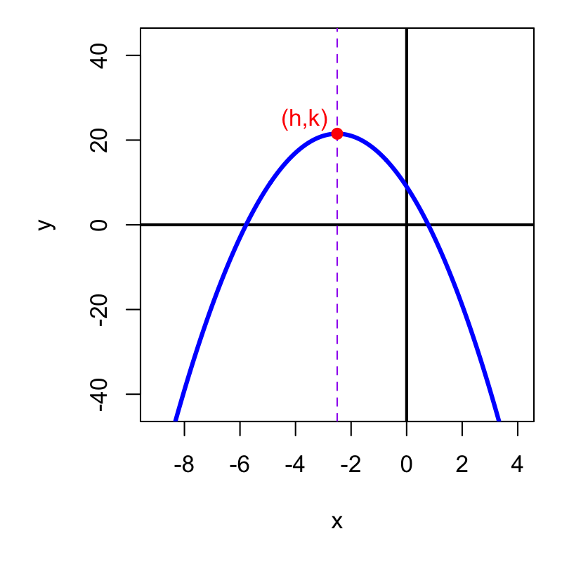

Using [the geometric significance of the quadratic formula](https://en.wikipedia.org/wiki/Quadratic_formula#Geometric_significance), calculate $h$, the horizontal coordinate of the vertex. *The tolerance is $\pm 0.01$.*

Look at the quadratic formula, which tells us if our quadratic function is in standard form, like $y=ax^2+bx+c$, then:

$$\text{roots of quadratic function} ~=~
\frac{-b}{2a}\pm\frac{\sqrt{b^2-4ac}}{2a}$$

We were given a quadratic function in standard form. Identify the parameters.

- The quadratic coefficient: $a=-2$
- The linear coefficient: $b=-10$
- The constant: $c=9$

The [the geometric significance of the quadratic formula](https://en.wikipedia.org/wiki/Quadratic_formula#Geometric_significance) tells us that $h=\frac{-b}{2a}$ and the distance of the roots to the axis of symmetry is $\frac{\sqrt{b^2-4ac}}{2a}$. Use the formula to calculate $h$.

$$\begin{align}
h &= \frac{-b}{2a} \\\\
&= \frac{-(-10)}{2(-2)} \\\\
&= -2.5
\end{align}$$

- The axis of symmetry is line $x=-2.5$.
- The vertex is point $(-2.5,\,21.5)$

Consider the [quadratic function](https://en.wikipedia.org/wiki/Quadratic_function) defined below.

$$f(x)~=~-3x^2+9x-6$$

Below, I've graphed $y=f(x)$, and I've included the axis of symmetry as a dashed purple line and the vertex as a filled red dot.

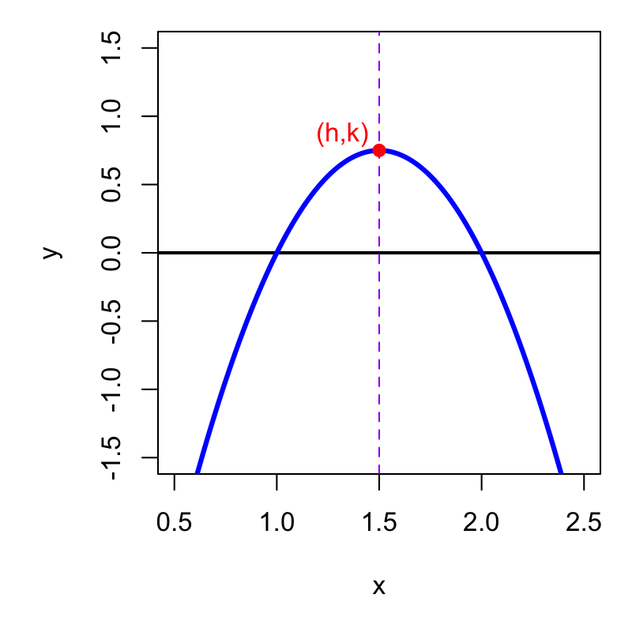

Using [the geometric significance of the quadratic formula](https://en.wikipedia.org/wiki/Quadratic_formula#Geometric_significance), calculate $h$, the horizontal coordinate of the vertex. *The tolerance is $\pm 0.01$.*

Look at the quadratic formula, which tells us if our quadratic function is in standard form, like $y=ax^2+bx+c$, then:

$$\text{roots of quadratic function} ~=~
\frac{-b}{2a}\pm\frac{\sqrt{b^2-4ac}}{2a}$$

We were given a quadratic function in standard form. Identify the parameters.

- The quadratic coefficient: $a=-3$
- The linear coefficient: $b=9$
- The constant: $c=-6$

The [the geometric significance of the quadratic formula](https://en.wikipedia.org/wiki/Quadratic_formula#Geometric_significance) tells us that $h=\frac{-b}{2a}$ and the distance of the roots to the axis of symmetry is $\frac{\sqrt{b^2-4ac}}{2a}$. Use the formula to calculate $h$.

$$\begin{align}
h &= \frac{-b}{2a} \\\\
&= \frac{-(9)}{2(-3)} \\\\
&= 1.5
\end{align}$$

- The axis of symmetry is line $x=1.5$.
- The vertex is point $(1.5,\,0.75)$

Consider the [quadratic function](https://en.wikipedia.org/wiki/Quadratic_function) defined below.

$$f(x)~=~6x^2-7x-5$$

Below, I've graphed $y=f(x)$, and I've included the axis of symmetry as a dashed purple line and the vertex as a filled red dot.

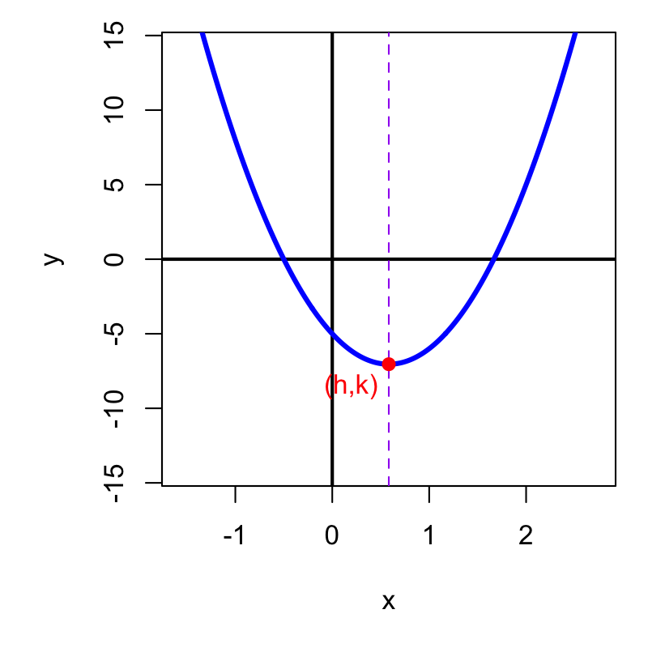

Using [the geometric significance of the quadratic formula](https://en.wikipedia.org/wiki/Quadratic_formula#Geometric_significance), calculate $h$, the horizontal coordinate of the vertex. *The tolerance is $\pm 0.01$.*

Look at the quadratic formula, which tells us if our quadratic function is in standard form, like $y=ax^2+bx+c$, then:

$$\text{roots of quadratic function} ~=~
\frac{-b}{2a}\pm\frac{\sqrt{b^2-4ac}}{2a}$$

We were given a quadratic function in standard form. Identify the parameters.

- The quadratic coefficient: $a=6$
- The linear coefficient: $b=-7$
- The constant: $c=-5$

The [the geometric significance of the quadratic formula](https://en.wikipedia.org/wiki/Quadratic_formula#Geometric_significance) tells us that $h=\frac{-b}{2a}$ and the distance of the roots to the axis of symmetry is $\frac{\sqrt{b^2-4ac}}{2a}$. Use the formula to calculate $h$.

$$\begin{align}
h &= \frac{-b}{2a} \\\\
&= \frac{-(-7)}{2(6)} \\\\
&= 0.5833333
\end{align}$$

- The axis of symmetry is line $x=0.5833333$.
- The vertex is point $(0.5833333,\,-7.0416667)$

Consider the [quadratic function](https://en.wikipedia.org/wiki/Quadratic_function) defined below.

$$f(x)~=~-8x^2+6x+11$$

Below, I've graphed $y=f(x)$, and I've included the axis of symmetry as a dashed purple line and I've marked the distance from the axis of symmetry to one of the roots with a red line segment labelled $w$.

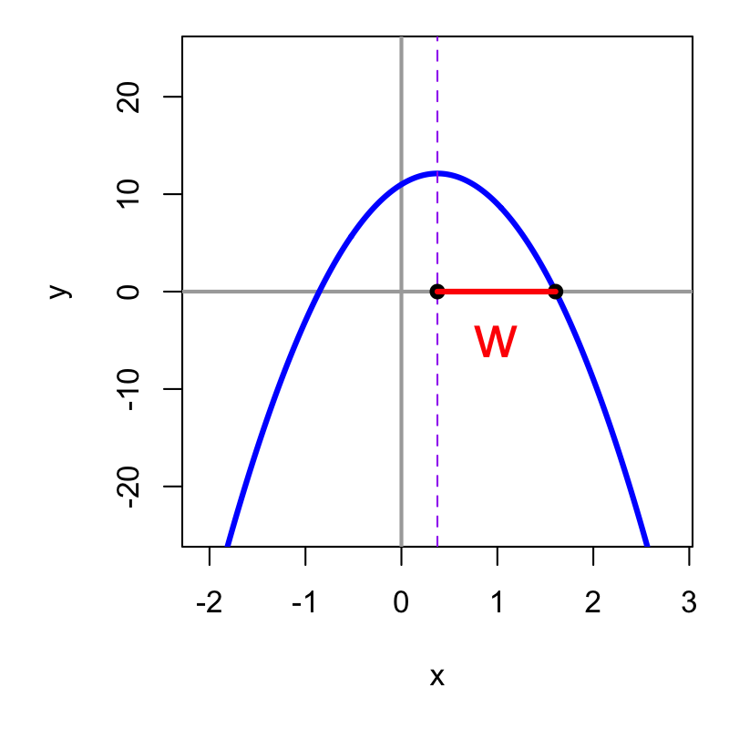

Using [the geometric significance of the quadratic formula](https://en.wikipedia.org/wiki/Quadratic_formula#Geometric_significance), calculate $w$, the distance between the axis of symmetry and one of the roots. *The tolerance is $\pm 0.01$.*

Look at the quadratic formula, which tells us if our quadratic function is in standard form, like $y=ax^2+bx+c$, then:

$$\text{roots of quadratic function} ~=~
\frac{-b}{2a}\pm\frac{\sqrt{b^2-4ac}}{2a}$$

We were given a quadratic function in standard form. Identify the parameters.

- The quadratic coefficient: $a=-8$
- The linear coefficient: $b=6$
- The constant: $c=11$

The [the geometric significance of the quadratic formula](https://en.wikipedia.org/wiki/Quadratic_formula#Geometric_significance) tells us that $h=\frac{-b}{2a}$ and the distance of the roots to the axis of symmetry is $w=\frac{\sqrt{b^2-4ac}}{|2a|}$. Use the formula to calculate $w$.

$$w~=~\frac{\sqrt{(6)^2-4(-8)(11)}}{|2(-8)|}$$

Simplify.

$$w~=~\frac{\sqrt{36+352}}{|-16|}$$

Simplify.

$$w~=~\frac{\sqrt{388}}{16}$$

Use a calculator.

$$w~=~1.2311072$$

Consider the [quadratic function](https://en.wikipedia.org/wiki/Quadratic_function) defined below.

$$f(x)~=~11x^2+4x-10$$

Below, I've graphed $y=f(x)$, and I've included the axis of symmetry as a dashed purple line and I've marked the distance from the axis of symmetry to one of the roots with a red line segment labelled $w$.

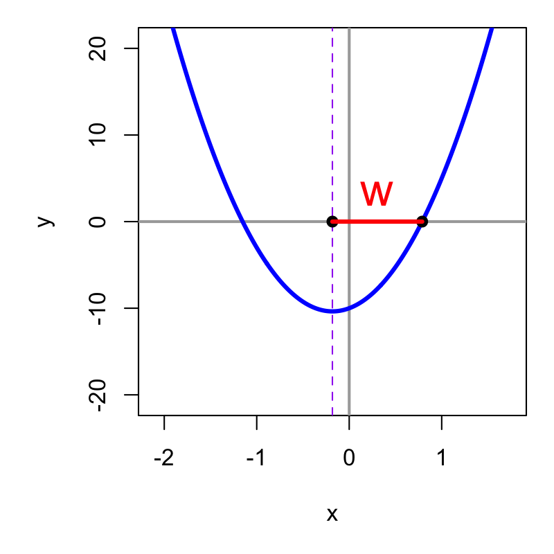

Using [the geometric significance of the quadratic formula](https://en.wikipedia.org/wiki/Quadratic_formula#Geometric_significance), calculate $w$, the distance between the axis of symmetry and one of the roots. *The tolerance is $\pm 0.01$.*

Look at the quadratic formula, which tells us if our quadratic function is in standard form, like $y=ax^2+bx+c$, then:

$$\text{roots of quadratic function} ~=~
\frac{-b}{2a}\pm\frac{\sqrt{b^2-4ac}}{2a}$$

We were given a quadratic function in standard form. Identify the parameters.

- The quadratic coefficient: $a=11$
- The linear coefficient: $b=4$
- The constant: $c=-10$

The [the geometric significance of the quadratic formula](https://en.wikipedia.org/wiki/Quadratic_formula#Geometric_significance) tells us that $h=\frac{-b}{2a}$ and the distance of the roots to the axis of symmetry is $w=\frac{\sqrt{b^2-4ac}}{|2a|}$. Use the formula to calculate $w$.

$$w~=~\frac{\sqrt{(4)^2-4(11)(-10)}}{|2(11)|}$$

Simplify.

$$w~=~\frac{\sqrt{16+440}}{|22|}$$

Simplify.

$$w~=~\frac{\sqrt{456}}{22}$$

Use a calculator.

$$w~=~0.9706435$$

Consider the [quadratic function](https://en.wikipedia.org/wiki/Quadratic_function) defined below.

$$f(x)~=~-12x^2+5x+7$$

Below, I've graphed $y=f(x)$, and I've included the axis of symmetry as a dashed purple line and I've marked the distance from the axis of symmetry to one of the roots with a red line segment labelled $w$.

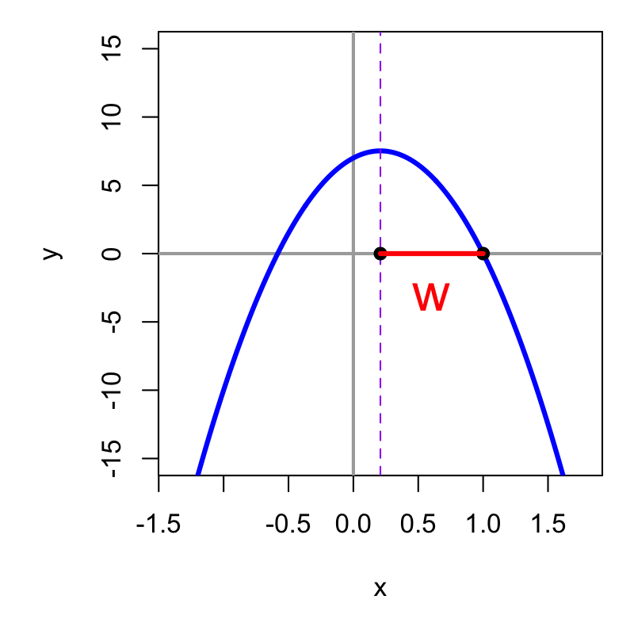

Using [the geometric significance of the quadratic formula](https://en.wikipedia.org/wiki/Quadratic_formula#Geometric_significance), calculate $w$, the distance between the axis of symmetry and one of the roots. *The tolerance is $\pm 0.01$.*

Look at the quadratic formula, which tells us if our quadratic function is in standard form, like $y=ax^2+bx+c$, then:

$$\text{roots of quadratic function} ~=~
\frac{-b}{2a}\pm\frac{\sqrt{b^2-4ac}}{2a}$$

We were given a quadratic function in standard form. Identify the parameters.

- The quadratic coefficient: $a=-12$
- The linear coefficient: $b=5$
- The constant: $c=7$

The [the geometric significance of the quadratic formula](https://en.wikipedia.org/wiki/Quadratic_formula#Geometric_significance) tells us that $h=\frac{-b}{2a}$ and the distance of the roots to the axis of symmetry is $w=\frac{\sqrt{b^2-4ac}}{|2a|}$. Use the formula to calculate $w$.

$$w~=~\frac{\sqrt{(5)^2-4(-12)(7)}}{|2(-12)|}$$

Simplify.

$$w~=~\frac{\sqrt{25+336}}{|-24|}$$

Simplify.

$$w~=~\frac{\sqrt{361}}{24}$$

Use a calculator.

$$w~=~0.7916667$$

Consider the [quadratic function](https://en.wikipedia.org/wiki/Quadratic_function) defined below.

$$f(x)~=~5x^2+12x-11$$

Below, I've graphed $y=f(x)$, and I've included the axis of symmetry as a dashed purple line and I've marked the distance from the axis of symmetry to one of the roots with a red line segment labelled $w$.

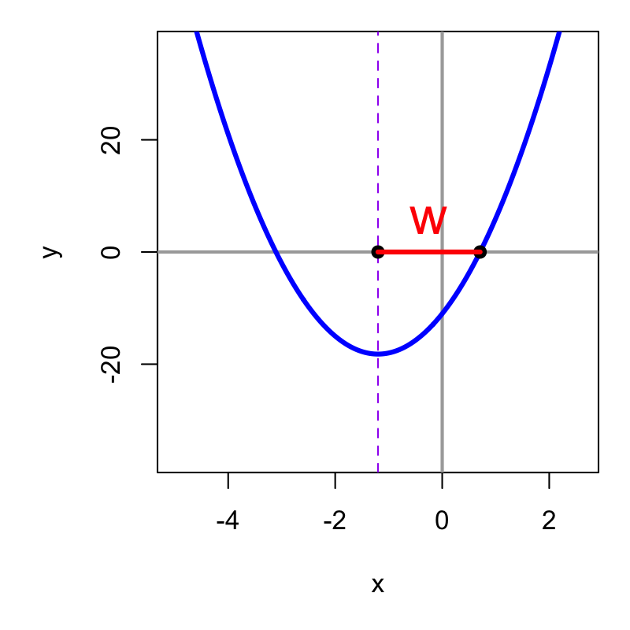

Using [the geometric significance of the quadratic formula](https://en.wikipedia.org/wiki/Quadratic_formula#Geometric_significance), calculate $w$, the distance between the axis of symmetry and one of the roots. *The tolerance is $\pm 0.01$.*

Look at the quadratic formula, which tells us if our quadratic function is in standard form, like $y=ax^2+bx+c$, then:

$$\text{roots of quadratic function} ~=~
\frac{-b}{2a}\pm\frac{\sqrt{b^2-4ac}}{2a}$$

We were given a quadratic function in standard form. Identify the parameters.

- The quadratic coefficient: $a=5$
- The linear coefficient: $b=12$
- The constant: $c=-11$

The [the geometric significance of the quadratic formula](https://en.wikipedia.org/wiki/Quadratic_formula#Geometric_significance) tells us that $h=\frac{-b}{2a}$ and the distance of the roots to the axis of symmetry is $w=\frac{\sqrt{b^2-4ac}}{|2a|}$. Use the formula to calculate $w$.

$$w~=~\frac{\sqrt{(12)^2-4(5)(-11)}}{|2(5)|}$$

Simplify.

$$w~=~\frac{\sqrt{144+220}}{|10|}$$

Simplify.

$$w~=~\frac{\sqrt{364}}{10}$$

Use a calculator.

$$w~=~1.9078784$$

Consider the [quadratic function](https://en.wikipedia.org/wiki/Quadratic_function) defined below.

$$f(x)~=~3x^2-10x-12$$

Below, I've graphed $y=f(x)$, and I've included the axis of symmetry as a dashed purple line and I've marked the distance from the axis of symmetry to one of the roots with a red line segment labelled $w$.

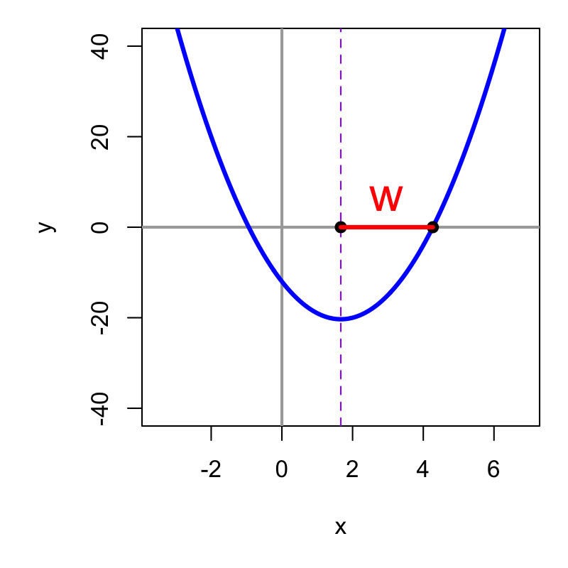

Using [the geometric significance of the quadratic formula](https://en.wikipedia.org/wiki/Quadratic_formula#Geometric_significance), calculate $w$, the distance between the axis of symmetry and one of the roots. *The tolerance is $\pm 0.01$.*

Look at the quadratic formula, which tells us if our quadratic function is in standard form, like $y=ax^2+bx+c$, then:

$$\text{roots of quadratic function} ~=~
\frac{-b}{2a}\pm\frac{\sqrt{b^2-4ac}}{2a}$$

We were given a quadratic function in standard form. Identify the parameters.

- The quadratic coefficient: $a=3$
- The linear coefficient: $b=-10$
- The constant: $c=-12$

The [the geometric significance of the quadratic formula](https://en.wikipedia.org/wiki/Quadratic_formula#Geometric_significance) tells us that $h=\frac{-b}{2a}$ and the distance of the roots to the axis of symmetry is $w=\frac{\sqrt{b^2-4ac}}{|2a|}$. Use the formula to calculate $w$.

$$w~=~\frac{\sqrt{(-10)^2-4(3)(-12)}}{|2(3)|}$$

Simplify.

$$w~=~\frac{\sqrt{100+144}}{|6|}$$

Simplify.

$$w~=~\frac{\sqrt{244}}{6}$$

Use a calculator.

$$w~=~2.6034166$$

Consider the [quadratic function](https://en.wikipedia.org/wiki/Quadratic_function) defined below.

$$f(x)~=~-12x^2-5x+7$$

Below, I've graphed $y=f(x)$, and I've included the axis of symmetry as a dashed purple line and I've marked the distance from the axis of symmetry to one of the roots with a red line segment labelled $w$.

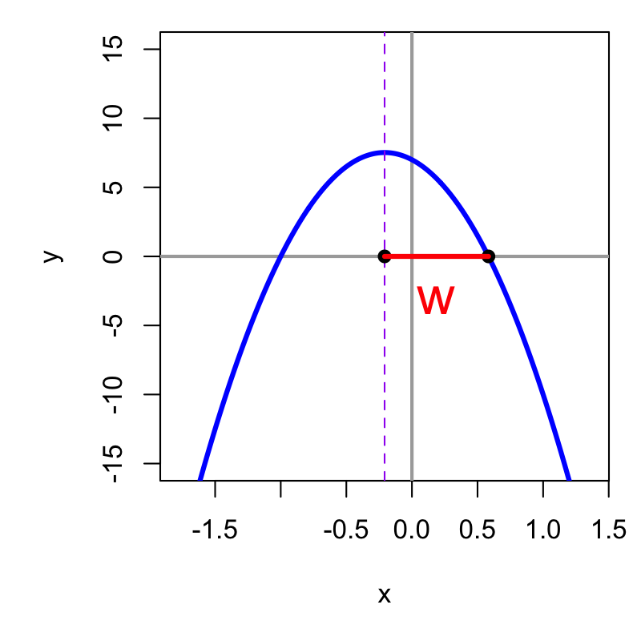

Using [the geometric significance of the quadratic formula](https://en.wikipedia.org/wiki/Quadratic_formula#Geometric_significance), calculate $w$, the distance between the axis of symmetry and one of the roots. *The tolerance is $\pm 0.01$.*

Look at the quadratic formula, which tells us if our quadratic function is in standard form, like $y=ax^2+bx+c$, then:

$$\text{roots of quadratic function} ~=~
\frac{-b}{2a}\pm\frac{\sqrt{b^2-4ac}}{2a}$$

We were given a quadratic function in standard form. Identify the parameters.

- The quadratic coefficient: $a=-12$
- The linear coefficient: $b=-5$
- The constant: $c=7$

The [the geometric significance of the quadratic formula](https://en.wikipedia.org/wiki/Quadratic_formula#Geometric_significance) tells us that $h=\frac{-b}{2a}$ and the distance of the roots to the axis of symmetry is $w=\frac{\sqrt{b^2-4ac}}{|2a|}$. Use the formula to calculate $w$.

$$w~=~\frac{\sqrt{(-5)^2-4(-12)(7)}}{|2(-12)|}$$

Simplify.

$$w~=~\frac{\sqrt{25+336}}{|-24|}$$

Simplify.

$$w~=~\frac{\sqrt{361}}{24}$$

Use a calculator.

$$w~=~0.7916667$$

Consider the [quadratic function](https://en.wikipedia.org/wiki/Quadratic_function) defined below.

$$f(x)~=~4x^2+7x+2$$

Below, I've graphed $y=f(x)$, and I've included the axis of symmetry as a dashed purple line and I've marked the distance from the axis of symmetry to one of the roots with a red line segment labelled $w$.

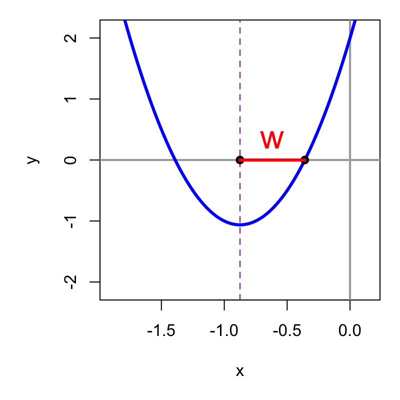

Using [the geometric significance of the quadratic formula](https://en.wikipedia.org/wiki/Quadratic_formula#Geometric_significance), calculate $w$, the distance between the axis of symmetry and one of the roots. *The tolerance is $\pm 0.01$.*

Look at the quadratic formula, which tells us if our quadratic function is in standard form, like $y=ax^2+bx+c$, then:

$$\text{roots of quadratic function} ~=~
\frac{-b}{2a}\pm\frac{\sqrt{b^2-4ac}}{2a}$$

We were given a quadratic function in standard form. Identify the parameters.

- The quadratic coefficient: $a=4$
- The linear coefficient: $b=7$
- The constant: $c=2$

The [the geometric significance of the quadratic formula](https://en.wikipedia.org/wiki/Quadratic_formula#Geometric_significance) tells us that $h=\frac{-b}{2a}$ and the distance of the roots to the axis of symmetry is $w=\frac{\sqrt{b^2-4ac}}{|2a|}$. Use the formula to calculate $w$.

$$w~=~\frac{\sqrt{(7)^2-4(4)(2)}}{|2(4)|}$$

Simplify.

$$w~=~\frac{\sqrt{49-32}}{|8|}$$

Simplify.

$$w~=~\frac{\sqrt{17}}{8}$$

Use a calculator.

$$w~=~0.5153882$$

Consider the [quadratic function](https://en.wikipedia.org/wiki/Quadratic_function) defined below.

$$f(x)~=~3x^2+9x-5$$

Below, I've graphed $y=f(x)$, and I've included the axis of symmetry as a dashed purple line and I've marked the distance from the axis of symmetry to one of the roots with a red line segment labelled $w$.

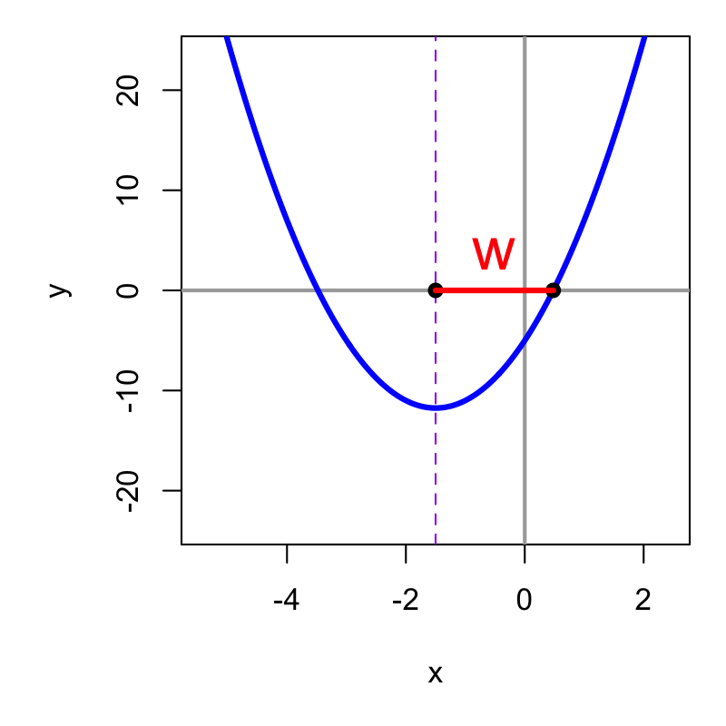

Using [the geometric significance of the quadratic formula](https://en.wikipedia.org/wiki/Quadratic_formula#Geometric_significance), calculate $w$, the distance between the axis of symmetry and one of the roots. *The tolerance is $\pm 0.01$.*

Look at the quadratic formula, which tells us if our quadratic function is in standard form, like $y=ax^2+bx+c$, then:

$$\text{roots of quadratic function} ~=~
\frac{-b}{2a}\pm\frac{\sqrt{b^2-4ac}}{2a}$$

We were given a quadratic function in standard form. Identify the parameters.

- The quadratic coefficient: $a=3$
- The linear coefficient: $b=9$
- The constant: $c=-5$

The [the geometric significance of the quadratic formula](https://en.wikipedia.org/wiki/Quadratic_formula#Geometric_significance) tells us that $h=\frac{-b}{2a}$ and the distance of the roots to the axis of symmetry is $w=\frac{\sqrt{b^2-4ac}}{|2a|}$. Use the formula to calculate $w$.

$$w~=~\frac{\sqrt{(9)^2-4(3)(-5)}}{|2(3)|}$$

Simplify.

$$w~=~\frac{\sqrt{81+60}}{|6|}$$

Simplify.

$$w~=~\frac{\sqrt{141}}{6}$$

Use a calculator.

$$w~=~1.979057$$